# Disciplina: Estudos Sociais dos Algorítmos e Inteligência Artificial

Docente: Profa Dra. Sylvia Iasulaitis; Discente: Antonio Andrade

08/06/2022

# 1. Introdução

A pandemia de COVID-19 causou efeitos nefastos à população mundial. Até a escrita deste ensaio, os dados dão conta de que, no Brasil, 666.971 vidas foram ceifadas pela COVID-19, e o número acumulado de casos confirmados atingiu patamares próximos à estratosfera, ou algo na ordem dos 31,14 milhões (https://ourworldindata.org/coronavirus/country/brazil - acesso em 04/06/2022).

No auge ou pico da pandemia, em 01 de Abril de 2021, foram registradas 3.107 mortes no território nacional (https://ourworldindata.org/coronavirus/country/brazil - acesso em 04/06/2022). Tendo em vista este cenário devastador de proporções globais, as entidades sanitárias e a “Organização Mundial de Saúde” (OMS) propuseram algumas medidas no sentido de conter o avanço da pandemia e por conseguinte as complicações entre os indivíduos em geral, e nos grupos vulneráveis (aqueles com comorbidades e idosos).

Dentre as sugestões propostas estão: manter distanciamento físico entre indivíduos de pelo menos 1 metro de distância; evitar multidões e contato muito próximo; uso da máscara facial devidamente ajustada quando o distanciamento físico não for possível e em ambientes mal ventilados; limpar as mãos frequentemente com álcool gel ou água e sabão; vacinar-se assim que chegar a sua vez (https://www.who.int/emergencies/diseases/novel-coronavirus-2019/advice-for-public).

E é exatamente neste último item sugerido que convergem as discussões as quais vão suscitar indiretamente o objeto de estudo do presente ensaio. Primeiro foram as pontuações referentes à leniência do poder público no enfrentamento das questões relacionadas à pandemia. A vacina é apontada como uma medida eficaz para conter a pandemia. Inicialmente havia uma escassez de vacinas disponíveis no mercado farmacêutico internacional.

A demora ou ausência na declaração de interesse de compra de vacina frente às multinacionais produtoras poderia representar um risco de aquisição de um número menor de doses necessárias para atender com equidade toda a população brasileira. Outro ponto levantado foram as questões referentes ao superfaturamento do preço das doses a serem adquiridas, além da suspeição de desvio de dinheiro público para interesses particulares quando da compra das doses. Também foram levantadas suspeitas relativas ao desvio de verbas destinadas à compra de insumos necessários ao enfrentamento da pandemia, aventando-se a hipótese de desvio de dinheiro do erário público por parte dos Estados e municípios que compõem a Federação.

Como se não bastassem todos esses inconvenientes que poderiam ou não se confirmar no curso das investigações e depoimentos à CPI, numa situação de calamidade pública declarada, ainda pululavam as denúncias de “fakenews” relativas às questões vacinais, que de certa maneira afugentavam alguns setores da sociedade que ainda tinham receio da vacinação.

Visando analisar tais questões, instaurou-se em abril de 2021 a Comissão Parlamentar de Inquérito da Pandemia (CPIPANDEMIA). O seu principal objetivo era “investigar o Governo Federal, em razão da violação dos direitos fundamentais básicos de toda a população brasileira à vida e à saúde, e por ter deixado de seguir as orientações científicas de autoridades sanitárias de caráter mundial, incluindo a Organização Mundial de Saúde” (https://legis.senado.leg.br/comissoes/mnas?codcol=2441&tp=3 acesso em 04/06/2022).

O desenrolar da CPI foi marcado por depoimentos, pronunciamentos e discursos. É sabido que os discursos políticos remontam a tempos antigos [@Champion, 2000; MacDonald - google]. No transcorrer das sessões dos depoimentos na CPIPANDEMIA, era de se esperar que a tônica dos discursos proferidos pelos parlamentares ficasse concentrada nas questões pertinentes às investigações sob suspeição à época. O cerne dos trabalhos parlamentares da comisssão seria investigar pontos de interesse público, à luz de demonstrações, argumentos e proposições racionais, lógicas e científicas dos fatos investigados. Entretanto, e ao que parece, os discursos foram revestidos de interesses políticos, visando, por exemplo, enaltecer as medidas tomadas e em vigor (governo), ou com vistas às próximas eleições (oposição). Para entender o que é política, precisamos saber o que os atores políticos estão dizendo e escrevendo. A linguagem e a retórica são meios para entendimento dos conflitos políticos (MacDonald, 2019). Os discursos podem ser, em certa medida, instrumentos para inferir sobre agendas políticas e influenciar a opinião dos eleitores (Oliveira,2020; Brasil, Capella, 2019).

O uso de textos como dados tem crescido exponencialmente nas ciências políticas (Grimmer & Stewart, 2013; Lucas et al., 2015; Tucker et al., 2020). O texto sempre foi fonte de dados nas ciências políticas, e recentemente, devido ao desenvolvimento de pacotes ou softwares de análises, tornou-se possível a análise quantitativa de um enorme volume de textos (Wilkerson and Casas, 2017).

Davi Moreira (2016) analisou mais de 127 mil pronunciamentos de 2.000 oradores diferentes ao longo de 15 anos de atividade parlamentar na Câmara dos deputados. Ele concluiu que as atividades destes integrantes do pleito não são integralmente pautadas pela relação governo-oposição, indicando influencias de outras variáveis como questões ideológicas, de gênero, senioridade e a própria popularidade do parlamentar. Izumi 2017, usando texto como fonte de dados, analisou o discurso de senadores brasileiros de 1995 a 2014 para estimar a posição política dos partidos brasileiros. Identificou que, ao invés de uma divisão ideológica, os discursos dos senadores organizam os partidos políticos representando o conflito entre governo e oposição.

Diante destas observações, o objetivo deste ensaio é resposnder à questão: “existem diferenças nos discursos proferidos pelos senadores governistas e de oposição durante a realização da CPI da Pandemia?”.

Neste ensaio foi utilizado a análise quantitativa dos discursos transcritos pelos senadores durante a realização da CPI da pandemia. A análise inicial focou apenas no discurso de 3 senadores de cada um dos grupos (gorvernista e de oposição).

A princípio, a base de dados usada será de um “wabscraping” de discursos da “CPI da Pandemia”, disponivel em https://basedosdados.org/dataset/br-senado-cpipandemia .

Antes de enumer os aschados, chegar a quaisquers conclusões ou fazer alguma inferencia, acredito que seja necessário enfatizar que como escritor deste ensaio, declaro não haver nenhum conflito de interesse inerente a estas discussões, assegurando para inteiramente manter um esforço hercúleo de neutralidade, reservando ou concentrando apenas às questões metodológicas usadas para tentar responder às questões ou hipóteses formuladas.

```r
# Carregando os pacotes necessários:

library(tidyverse)
library(ggExtra)
library(magrittr)
library(lubridate)
library(stringr)
library(stopwords)      #p/palavras "quebra de frase"
library(tm)             #text mining
library(tidytext)

library(lexiconPT) #lexicon da Língua Portuguesa
```

## 2 Importação doS arquivoS

```r
# Dados disponíveis em <https://basedosdados.org/dataset/br-senado-cpipandemia> .
#
discursos <- read_csv('discursos.csv') # "rodando" discurso no console, observa-se que ele já está no formato de um tibble.
head(discursos, 10)
```

```
## # A tibble: 10 x 21
##    sequencial_sess~ data_sessao sigla_partido sigla_uf_partido bloco_parlament~
##    <chr>            <date>      <chr>         <chr>            <chr>
##  1 01               2021-04-27  PSD           BA               <NA>
##  2 01               2021-04-27  PP            PI               Bloco Parlament~
##  3 01               2021-04-27  PSD           BA               <NA>
##  4 01               2021-04-27  PP            PI               Bloco Parlament~
##  5 01               2021-04-27  PSD           BA               <NA>
##  6 01               2021-04-27  PP            PI               Bloco Parlament~
##  7 01               2021-04-27  PSD           BA               <NA>
##  8 01               2021-04-27  PP            PI               Bloco Parlament~
##  9 01               2021-04-27  PSD           BA               <NA>
## 10 01               2021-04-27  PP            PI               Bloco Parlament~
## # ... with 16 more variables: nome_discursante <chr>, genero_discursante <chr>,
## #   categoria_discursante <chr>, texto_discurso <chr>,
## #   horario_inicio_discurso <time>, horario_fim_discurso <time>,
## #   duracao_discurso <dbl>, sinalizacao_pela_ordem <chr>,
## #   sinalizacao_questao_ordem <chr>, sinalizacao_fora_microfone <chr>,
## #   sinalizacao_responder_questao_ordem <chr>,
## #   sinalizacao_por_videoconferencia <chr>, sinalizacao_para_interpelar <chr>,
## #   sinalizacao_para_expor <chr>, sinalizacao_para_depor <chr>,
## #   sinalizacao_como_presidente <chr>
```

## Categoria dos discursantes:

Categoria dos discursantes (Senador/a):

```r
# GOVERNISTAS:
discursos_senadores_governistas <- filter(discursos, categoria_discursante == 'Senador/a')%>%
        filter(nome_discursante == "JORGINHO MELLO" | nome_discursante == "CIRO NOGUEIRA" | nome_discursante == "MARCOS ROGÉRIO") %>%
        select(nome_discursante,  texto_discurso)
```

```r
# OPOSIÇÃO:
discursos_senadores_oposicao <- filter(discursos, categoria_discursante == 'Senador/a')%>%
        filter(nome_discursante == "HUMBERTO COSTA" | nome_discursante == "TASSO JEREISSATI" | nome_discursante == "OTTO ALENCAR")%>%
        select(nome_discursante,  texto_discurso)
```

## Preprocessamento padrão do texto.

```r
# GOVERNISTAS
discursos_senadores_governistas$texto_discurso <- discursos_senadores_governistas$texto_discurso %>%
    str_to_lower() %>%                      # Caixa baixa.
    str_replace_all(" *-+ *", "") %>%       # Remove hífen.
    str_replace_all("[[:punct:]]", " ") %>% # Pontuação por espaço.
    removeNumbers() %>%                     # Remove números.
    trimws()                                # Sem espaços nas bordas.
```

```r
# OPOSIÇÃO
discursos_senadores_oposicao$texto_discurso <- discursos_senadores_oposicao$texto_discurso %>%
    str_to_lower() %>%                      # Caixa baixa.
    str_replace_all(" *-+ *", "") %>%       # Remove hífen.
    str_replace_all("[[:punct:]]", " ") %>% # Pontuação por espaço.
    removeNumbers() %>%                     # Remove números.
    trimws()                                # Sem espaços nas bordas.
```

## Remoção das stop words.

```r
# GOVERNISTAS
discursos_senadores_governistas$texto_discurso <- discursos_senadores_governistas$texto_discurso %>%
    removeWords(words = c("bom", "muito", "pouco", "obrigado","obrigada", "dar", "sa", "favor", "roberto", "sr", "presidente", "v", "exa","sras", "srs", #removento obrigado e obrigada
                          stopwords('pt')))
```

```r
# OPOSIÇÃO
discursos_senadores_oposicao$texto_discurso <- discursos_senadores_oposicao$texto_discurso %>%
    removeWords(words = c("bom", "muito", "pouco", "obrigado","obrigada", "dar", "sa", "favor", "roberto", "sr", "presidente","v", "exa", "sras", "srs",#removento obrigado e obrigada
                          stopwords('pt')))
```

## Realizando a “tokenização” do texto.

```r
# GOVERNISTAS
discursos_senadores_gov_unnested <- discursos_senadores_governistas %>%
        unnest_tokens(term, texto_discurso)
        # o primeiro argumento da fç unnest_tokens é o novo nome da coluna de saída que será criada, e o # segundo é a fonte, de onde será retirada.
# Notar que o número da linha de onde a palavra veio é mantido.

discursos_senadores_gov_unnested
```

```
## # A tibble: 61,258 x 2
##    nome_discursante term
##    <chr>            <chr>
##  1 CIRO NOGUEIRA    senadores
##  2 CIRO NOGUEIRA    achava
##  3 CIRO NOGUEIRA    deveríamos
##  4 CIRO NOGUEIRA    suspender
##  5 CIRO NOGUEIRA    atual
##  6 CIRO NOGUEIRA    sessão
##  7 CIRO NOGUEIRA    sanado
##  8 CIRO NOGUEIRA    vício
##  9 CIRO NOGUEIRA    vejo
## 10 CIRO NOGUEIRA    ser
## # ... with 61,248 more rows
```

```r
# OPOSIÇÃO
discursos_senadores_opo_unnested <- discursos_senadores_oposicao %>%
        unnest_tokens(term, texto_discurso)
        # o primeiro argumento da fç unnest_tokens é o novo nome da coluna de saída que será criada, e o # segundo é a fonte, de onde será retirada.
# Notar que o número da linha de onde a palavra veio é mantido.

discursos_senadores_opo_unnested
```

```
## # A tibble: 60,337 x 2
##    nome_discursante term
##    <chr>            <chr>
##  1 OTTO ALENCAR     invocando
##  2 OTTO ALENCAR     proteção
##  3 OTTO ALENCAR     deus
##  4 OTTO ALENCAR     declaro
##  5 OTTO ALENCAR     aberta
##  6 OTTO ALENCAR     sessão
##  7 OTTO ALENCAR     eleição
##  8 OTTO ALENCAR     quórum
##  9 OTTO ALENCAR     suficiente
## 10 OTTO ALENCAR     abertura
## # ... with 60,327 more rows
```

## Calculando a polaridade

```r
# uma amostra do dicionario de termos rotulados

sample_n(oplexicon_v3.0, size = 20) %>%
    arrange(polarity)
```

```
##                term     type polarity polarity_revision
## 1          apanhado      adj       -1                 A
## 2         bombeados      adj       -1                 A
## 3         cavilosas      adj       -1                 A
## 4         possuidos      adj       -1                 A
## 5         resfriado      adj       -1                 A
## 6        videirinho      adj       -1                 A
## 7           injusto      adj       -1                 M
## 8    insustentaveis      adj       -1                 M
## 9     inconclusivas      adj       -1                 M
## 10   apresentadoras      adj        0                 M
## 11  desnaturalizada      adj        0                 A
## 12     liquidificar       vb        0                 A
## 13      republicana      adj        0                 M
## 14      expositivos      adj        0                 M
## 15      inalterados      adj        0                 A
## 16        acarretar       vb        1                 A
## 17            #deus     htag        1                 A
## 18 lancar luz sobre vb n prp        1                 A
## 19        boa aluna      adj        1                 A
## 20        embatucar       vb        1                 A
```

```r
# Contagem por polaridade.
oplexicon_v3.0 %>%
    count(polarity, sort = TRUE)
```

```
##   polarity     n
## 1       -1 14569
## 2        0  9002
## 3        1  8620
```

```r
# Contagem por classe gramatical.
oplexicon_v3.0 %>%
    count(type, sort = TRUE)
```

```
##           type     n
## 1          adj 24475
## 2           vb  6889
## 3         htag   471
## 4 vb det n prp   103
## 5     vb n prp    91
## 6       vb adj    74
## 7         emot    66
## 8       vb adv    22
```

```r
# GOVERNO

# Faz o a junção por interseção.
tb_sen_gov <- inner_join(discursos_senadores_gov_unnested,
                     oplexicon_v3.0[, c("term", "polarity")],
                     by = c("term" = "term"))

# Agora os termos têm sua polaridade presente na tabela.
sample_n(tb_sen_gov, size = 20)
```

```
## # A tibble: 20 x 3
##    nome_discursante term          polarity
##    <chr>            <chr>            <int>
##  1 MARCOS ROGÉRIO   diferente            0
##  2 JORGINHO MELLO   maior                0
##  3 JORGINHO MELLO   dados                0
##  4 MARCOS ROGÉRIO   sentido             -1
##  5 MARCOS ROGÉRIO   inicial              0
##  6 MARCOS ROGÉRIO   protegidos          -1
##  7 MARCOS ROGÉRIO   passada             -1
##  8 MARCOS ROGÉRIO   movimentar           1
##  9 MARCOS ROGÉRIO   atuar                0
## 10 MARCOS ROGÉRIO   encaminhada          1
## 11 MARCOS ROGÉRIO   verdadeira           1
## 12 MARCOS ROGÉRIO   interrompidas       -1
## 13 MARCOS ROGÉRIO   passada             -1
## 14 MARCOS ROGÉRIO   mandados             0
## 15 JORGINHO MELLO   primeiro             0
## 16 CIRO NOGUEIRA    perfeito             1
## 17 MARCOS ROGÉRIO   pedido               1
## 18 MARCOS ROGÉRIO   maneira              1
## 19 MARCOS ROGÉRIO   cuidados             1
## 20 MARCOS ROGÉRIO   ser                  1
```

```r
# OPOSIÇÃO
tb_sen_opo <- inner_join(discursos_senadores_opo_unnested,
                     oplexicon_v3.0[, c("term", "polarity")],
                     by = c("term" = "term"))

# Agora os termos tem sua polaridade presente na tabela.
sample_n(tb_sen_opo, size = 20)
```

```
## # A tibble: 20 x 3
##    nome_discursante term         polarity
##    <chr>            <chr>           <int>
##  1 TASSO JEREISSATI discutir           -1
##  2 OTTO ALENCAR     sabe                1
##  3 OTTO ALENCAR     feito               1
##  4 HUMBERTO COSTA   caro               -1
##  5 HUMBERTO COSTA   pessoal             0
##  6 HUMBERTO COSTA   nebulosas          -1
##  7 TASSO JEREISSATI grande              0
##  8 OTTO ALENCAR     poder               0
##  9 HUMBERTO COSTA   dizer               0
## 10 OTTO ALENCAR     levar              -1
## 11 OTTO ALENCAR     acompanhados        0
## 12 HUMBERTO COSTA   feito               1
## 13 HUMBERTO COSTA   passado            -1
## 14 OTTO ALENCAR     vi                  1
## 15 TASSO JEREISSATI maior               0
## 16 HUMBERTO COSTA   americana           0
## 17 HUMBERTO COSTA   principal           0
## 18 HUMBERTO COSTA   primeiro            0
## 19 OTTO ALENCAR     dizer               0
## 20 OTTO ALENCAR     chegar             -1
```

# Faz a agregação da polaridade por documento.

```r
# GOVERNO

tb_gov_agregada <- tb_sen_gov %>%
    group_by(nome_discursante) %>%
    summarise(soma = sum(polarity),
              n = n(),
              sentiment = soma/n)
tb_gov_agregada
```

```
## # A tibble: 3 x 4
##   nome_discursante  soma     n sentiment
##   <chr>            <int> <int>     <dbl>
## 1 CIRO NOGUEIRA      144   931     0.155
## 2 JORGINHO MELLO     307  1847     0.166
## 3 MARCOS ROGÉRIO    1176  7790     0.151
```

```r
# OPOSIÇÃO

tb_opo_agregada <- tb_sen_opo %>%
    group_by(nome_discursante) %>%
    summarise(soma = sum(polarity),
              n = n(),
              sentiment = soma/n)
tb_opo_agregada
```

```
## # A tibble: 3 x 4
##   nome_discursante  soma     n sentiment
##   <chr>            <int> <int>     <dbl>
## 1 HUMBERTO COSTA     941  4869     0.193
## 2 OTTO ALENCAR       693  4613     0.150
## 3 TASSO JEREISSATI   224  1198     0.187
```

# Desidade expírica kernel do escore de sentimento.

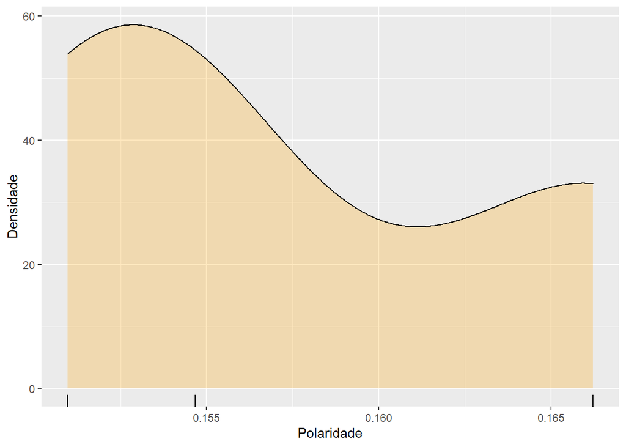

```r
# GOVERNO
ggplot(tb_gov_agregada, aes(x = sentiment)) +
    geom_density(fill = "orange", alpha = 0.25) +
    geom_rug() +
    labs(x = "Polaridade", y = "Densidade")
```

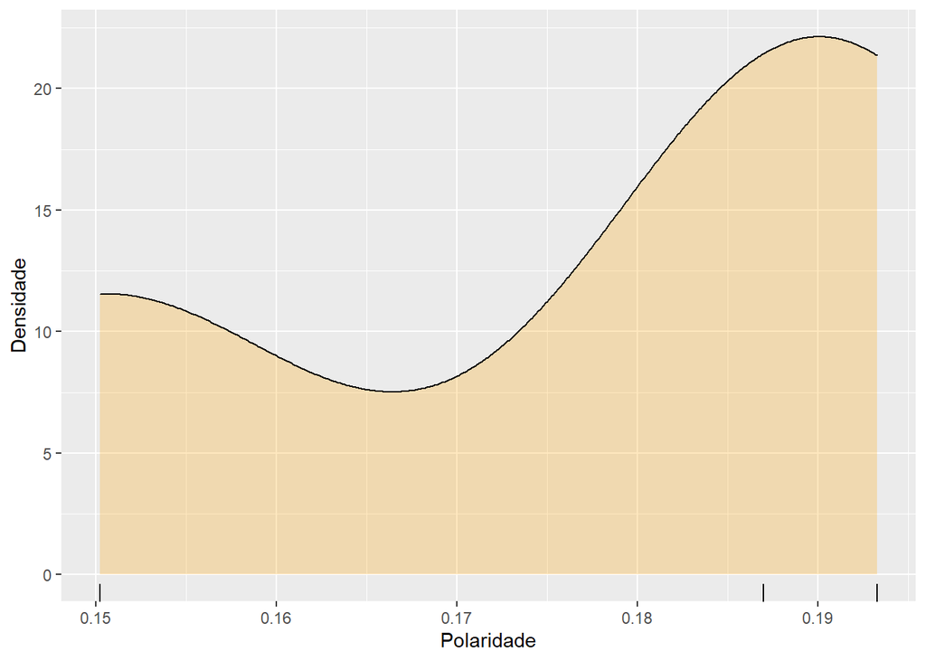

```r
# OPOSIÇÃO
ggplot(tb_opo_agregada, aes(x = sentiment)) +
    geom_density(fill = "orange", alpha = 0.25) +
    geom_rug() +
    labs(x = "Polaridade", y = "Densidade")
```

# Frequência relativa acumulada.

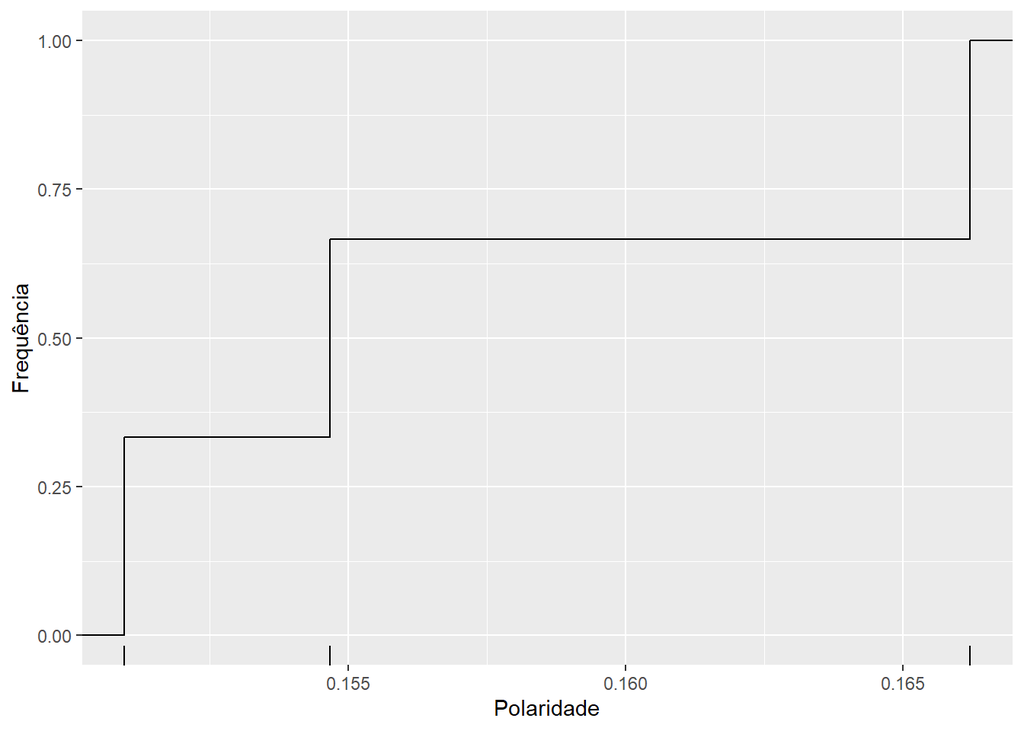

```r
# GOVERNO
ggplot(tb_gov_agregada, aes(x = sentiment)) +
    stat_ecdf() +
    geom_rug() +
    labs(x = "Polaridade", y = "Frequência")
```

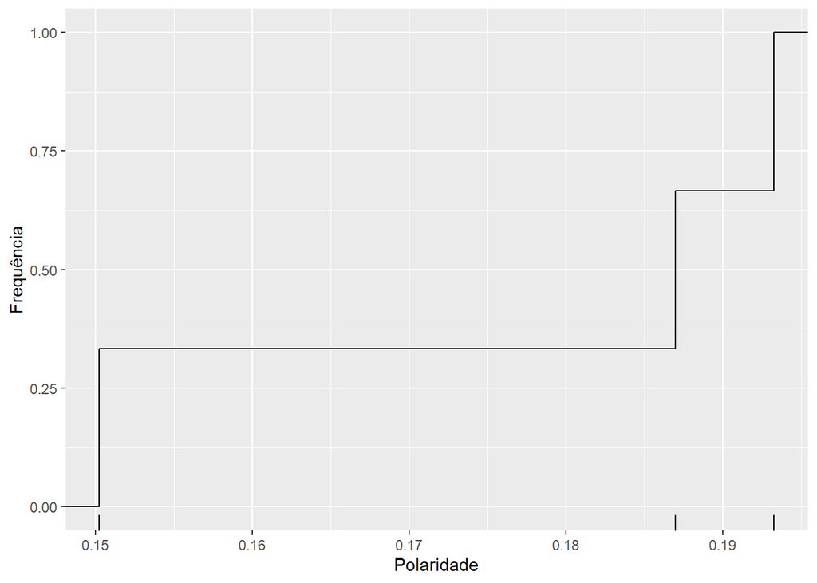

```r
# OPOSIÇÃO
ggplot(tb_opo_agregada, aes(x = sentiment)) +
    stat_ecdf() +
    geom_rug() +
    labs(x = "Polaridade", y = "Frequência")
```

# Termos mais frequentes por classe polar.

```r
# GOVERNISTAS

# Determina as frequências dos termos de polaridade não nula.
tb_words_gov <- tb_sen_gov %>%
    count(term, polarity, sort = TRUE) %>%
    filter(polarity != 0)

tb_cloud <- tb_words_gov %>%
    spread(key = "polarity", value = "n", fill = 0) %>%
    rename("negative" = "-1", "positive" = "1")
tb_cloud
```

```
## # A tibble: 1,235 x 3
##    term       negative positive
##    <chr>         <dbl>    <dbl>
##  1 abandonada        1        0
##  2 abjetos           1        0
##  3 abrangente        0        1
##  4 abrir             6        0
##  5 abrupta           1        0
##  6 absoluta          0       13
##  7 absoluto          0        4
##  8 abstrato          2        0
##  9 absurda           5        0
## 10 absurdas          1        0
## # ... with 1,225 more rows
```

```r
tb <- as.data.frame(tb_cloud[, c("negative", "positive")])
rownames(tb) <- tb_cloud$term
head(tb)
```

```
##            negative positive
## abandonada        1        0
## abjetos           1        0
## abrangente        0        1
## abrir             6        0
## abrupta           1        0
## absoluta          0       13
```

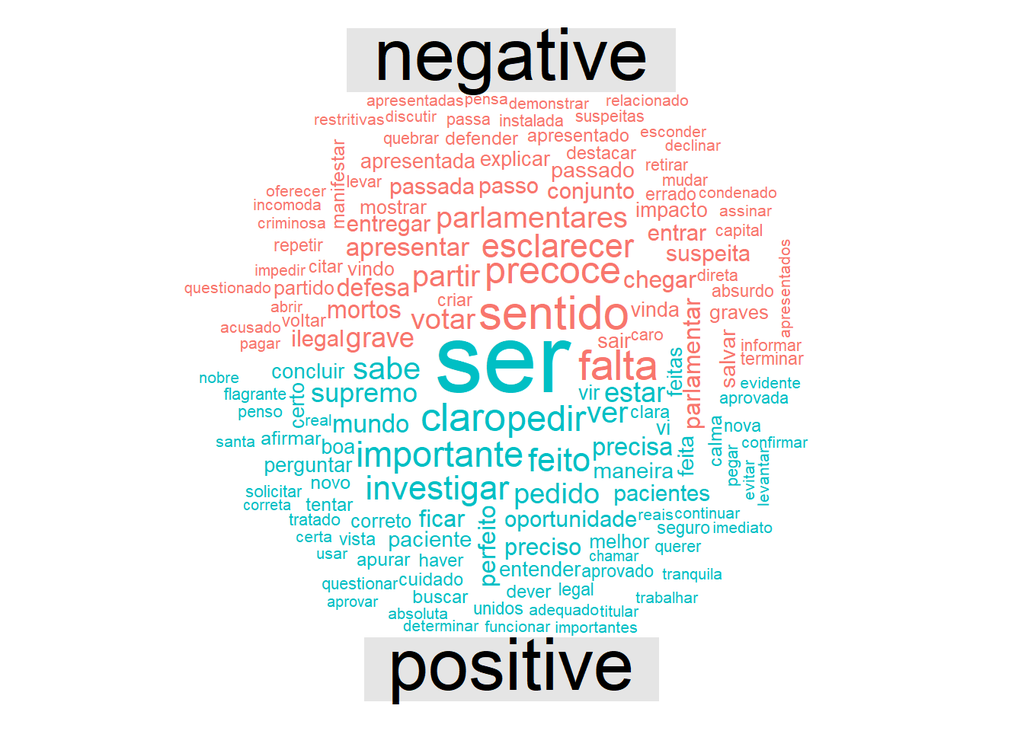

```r
library(wordcloud)
comparison.cloud(tb,
                 colors = c("#F8766D", "#00BFC4"),
                 max.words = min(nrow(tb), 150))
```

```r
# OPOSIÇÃO

tb_words_oposicao <- tb_sen_opo %>%
    count(term, polarity, sort = TRUE) %>%
    filter(polarity != 0)

tb_cloud <- tb_words_oposicao %>%
    spread(key = "polarity", value = "n", fill = 0) %>%
    rename("negative" = "-1", "positive" = "1")
tb_cloud
```

```
## # A tibble: 1,131 x 3
##    term       negative positive
##    <chr>         <dbl>    <dbl>
##  1 abalizada         0        1
##  2 abandonado        1        0
##  3 abolido           1        0
##  4 abrir             9        0
##  5 absoluta          0       10
##  6 absoluto          0        2
##  7 absolutos         0        1
##  8 absolver          1        0
##  9 absurda           2        0
## 10 absurdo          12        0
## # ... with 1,121 more rows
```

```r
tb <- as.data.frame(tb_cloud[, c("negative", "positive")])
rownames(tb) <- tb_cloud$term
head(tb)
```

```
##            negative positive
## abalizada         0        1
## abandonado        1        0
## abolido           1        0
## abrir             9        0
## absoluta          0       10
## absoluto          0        2
```

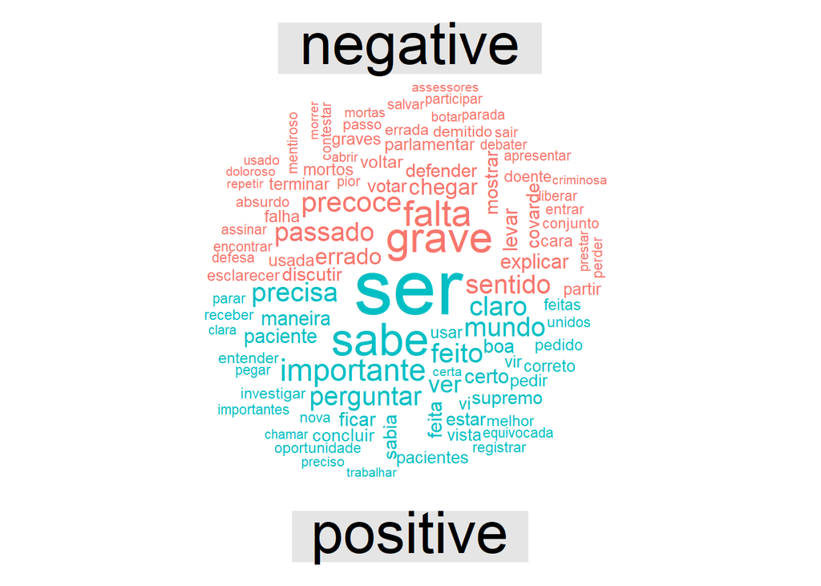

```r
library(wordcloud)
comparison.cloud(tb,
                 colors = c("#F8766D", "#00BFC4"),
                 max.words = min(nrow(tb), 100))
```

# Diversidade de palavras, presentes nos discursos

(A diversidade de palavras pode ser determinada pelo quociente entre entre o número total de palavras “únicas” (unique), pelo número total de palavras).

```r
# GOVERNO
total_palavras_gov <- nrow(na.omit(tb_sen_gov))
total_palavras_distintas_gov <- distinct(tb_sen_gov, term)

# >>> Entre os governistas, a diversidade de palavras foi algo em torno de 18.6 %
```

```r
# OPOSIÇÃO
total_palavras_opo <- nrow(na.omit(tb_sen_opo))
total_palavras_distintas_opo <- distinct(tb_sen_opo, term)

# >>> Entre os oposicionista, a diversidade de palavras ficou em 17.1 %
```

# Frequência de sentimentos negativos

freq_sentimentos_negativos_gov <- filter(tb_sen_gov, polarity == -1)

### Resposta: retornou um tibble com 2021 linhas

freq_sentimentos_negativos_opo <- filter(tb_sen_opo, polarity == -1)

### Resposta: retornou um tibble com 1943 linhas

# Apontamentos_Conclusões

Os dados apresentados perfazem um total de 7.016 discursos, sendo 4.395 destes proferidos pelos três senadores governistas (Ciro Nogueira, Jorginho Melo e Marcos Rogério) e 2621 discursos pelos senadores oposicionistas (Humberto Costa, Tasso Jereissati e Otto Alencar). Trata-se de um corpus de fonte de dados passivel de ser investigado com estas ferramentas disponíveis. Mais análises devem ser executadas para entender melhor a distribuição dos dados entre ambos os grupos.

Nas “wordclouds” não observa-se algo que tornem os grupos tão distintos, ou alguma palavra que se destaque entre os 2 grupos. Talvez entre os oposicionistas as palavras “falta” e “grave”, numa alusão à gravidade da pandemia.

A diversidade de palavras também apresentou distribuição semelhante, com palavras distintas perfazendo um total de 18.6% para governistas e 17.1 % entre os oposicionistas. A frequência de sentimentos negativos também se mostrou equiparada ou semelhante entre os grupos distintos. Nestes casos, para uma análise mais pormenorizada, cabe a realização de um teste-t para a comparação da diferença entre os 2 grupos.

# Referências

Brasil, Felipe Gonçalves; Capella, Ana Claudia Niedhardt. Agenda governamental brasileira: uma análise da capacidade e diversidade nas prioridades em políticas públicas no período de 2003 a 2014. Cadernos Gestão Pública e Cidadania. São Paulo, v. 24, n. 78, p.1-22. 2019

Cordeiro Moreira, Davi. Com a palavra os nobres deputados - frequencia e ênfase temática dos discursos dos parlamentares brasileiros. 2016. Tese (Doutorado em Ciência Política) – Faculdade de Filosofia, Letras e Ciências Humanas, Universidade de São Paulo, 2016. DOI 10.11606/T.8.2016.tde-04112016-124733. Disponível em: https://teses.usp.br/teses/disponiveis/8/8131/tde-04112016-124733/pt-br.php. Acesso em: 01 jun. 2022.

Grimmer, J., & Stewart, B. (2013). Text as Data: The Promise and Pitfalls of Automatic Content Analysis Methods for Political Texts. Political Analysis, 21(3), 267-297. doi:10.1093/pan/mps028

Lucas, C.; Nielsen, R.; Roberts, M.; Stewart, B.; Storer, A.; & Tingley, D. (2015). Computer-Assisted Text Analysis for Comparative Politics. Political Analysis, 23(2), 254-277. doi:10.1093/pan/mpu019

MacDonald, Michael. The Oxford Handbook of Rethorical Studies. Oxford University Press, 2017. E-book. Disponível em: https://play.google.com/books/reader?id=_S82DwAAQBAJ&pg=GBS.PA9.w.1.1.163_221. Acesso em: 1 jun. 2022.

Our World in Data. Disponivel em: https://ourworldindata.org/coronavirus/country/brazil. Acesso em 01/06/2022.

SILGE, J.; RODINSON, D. Text Mining with R: A tidy approach. 1st ed. O’Reilly Media, 2017.

Tucker, Ethan C.; Capps, Colton J.; Shamir, Lior. A data science approach to 138 years of congressional speeches. Heliyon, v.6, Issue 8, 2020, e04417, ISSN 2405-8440, DOI: 10.1016/j.heliyon.2020.e04417. Disponível em: https://www.sciencedirect.com/science/article/pii/S2405844020312615

Wilkerson, John; Casas, Andreau. Large-Scale Computerized Text Analysis in Political Science: Opportunities and Challenges. Anual Review of Political Science. v.20, p.529-544, 2017.

World Health Organization. https://www.who.int/emergencies/diseases/novel-coronavirus-2019/advice-for-public

Yoshida Izumi, Maurício. Velhas questões, novos métodos: posições, agenda, ideologia e dinheiro na política brasileira. 2017. Tese (Doutorado em Ciência Política) - Faculdade de Filosofia, Letras e Ciências Humanas, Universidade de São Paulo, 2017. DOI 10.11606/T.8.2018.tde-11042018-114905 Disponível em: https://teses.usp.br/teses/disponiveis/8/8131/tde-11042018-114905/pt-br.php Acesso em: 01 jun. 2022.